# MEA_beatrate_peakhight

RvH

2023-09-07

# First MEA test with Drug exposures

##Import data

```r
files <- list.files("Export1/", full.names = TRUE, pattern = ").csv")
if(!file.exists("beatrate_peakthight.rData")){

dat <- data.frame()
for(i in files){
df <- read_csv(i, skip = 154, n_max = 20) ##Select proper part of excelsheet
df <- df %>% pivot_longer(2:769, names_to = "Well", values_to = "blah") %>%
  pivot_wider(names_from = `Measurement`, values_from = blah) %>%
  filter(`Number Of Beats` > 0) %>%
  mutate(file = substr(i, 9, nchar(i))) %>%
  separate(Well,  into = c("Well", "Electrode"))
dat <- rbind(dat,df)
print(paste("merging dat and", i))
}
dat <- dat %>% mutate(Settings =  case_when( ##extract name from file and create groups
          str_detect(file, "(001)") ~ "Baseline",
          str_detect(file, "addition_1") ~ "Dose 1",
          str_detect(file, "80_min") ~ "Dose 2_80 min",
          TRUE ~ "Dose 2"
          )) %>% select(file, Settings, everything())
save(dat, file = "beatrate_peakthight.rData")
} else {
  load("beatrate_peakthight.rData")
}

Plate_layout <- read_csv("Plate_layout.csv")
dat <- right_join(dat, Plate_layout, by = c("Well")) %>% ##merge with plate layout
  mutate(Concentration = case_when(
    str_detect(Settings, "Dose 1") ~ Concentration.1,
    str_detect(Settings, "Dose 2") ~ Concentration.2,
    TRUE ~ 0))
dat <- dat %>% filter(Settings == "Baseline") %>% select(Well, Electrode) %>% left_join(dat) %>% ##select only baseline active electrodes
  filter(Settings == "Dose 2") %>% select(Well, Electrode) %>% left_join(dat) ##select all wells which are still active at dose 2
dat <- dat %>% select(file, Settings, Well, Drug, Concentration, everything())

glimpse(dat)
```

```
## Rows: 649
## Columns: 28
## $ file                           <chr> "Batch_230818_RvH23D002_MEA_drug_test_D…
## $ Settings                       <chr> "Baseline", "Dose 1", "Dose 2", "Dose 2…
## $ Well                           <chr> "A5", "A5", "A5", "A5", "A5", "A5", "A5…
## $ Drug                           <chr> "DMSO", "DMSO", "DMSO", "DMSO", "DMSO",…
## $ Concentration                  <dbl> 0.000, 0.001, 0.010, 0.010, 0.000, 0.00…
## $ Electrode                      <chr> "22", "22", "22", "22", "23", "23", "23…
## $ `Number Of Beats`              <dbl> 17, 24, 29, 16, 17, 24, 29, 16, 17, 24,…
## $ `Number Of FPD Beats`          <dbl> 0, 0, 12, 0, 0, 0, 13, 0, 0, 0, 13, 1, …
## $ `Beat Period Mean (s)`         <dbl> 6.644482, 4.695335, 4.069790, 7.233049,…
## $ `Beat Period StdDev (s)`       <dbl> 0.916185, 0.086542, 0.559180, 1.568474,…
## $ `Beat Period Median (s)`       <dbl> 6.457683, 4.675559, 4.395153, 7.147002,…
## $ `Beat Period MAD (s)`          <dbl> 0.637344, 0.038838, 0.300300, 1.029388,…
## $ `Beat Period Irregularity (%)` <dbl> 13.788661, 1.843147, 13.739765, 21.6848…
## $ `Spike Slope Mean (V / s)`     <dbl> -0.763454, -0.883779, -0.837303, -0.817…
## $ `Spike Slope StdDev (V / s)`   <dbl> 0.014850, 0.015548, 0.015636, 0.023823,…
## $ `Spike Slope Median (V / s)`   <dbl> -0.763037, -0.886366, -0.837296, -0.822…
## $ `Spike Slope MAD (V / s)`      <dbl> 0.008392, 0.009583, 0.007332, 0.007575,…
## $ `Spike Amplitude Mean (mV)`    <dbl> 0.422, 0.478, 0.456, 0.454, 0.360, 0.40…
## $ `Spike Amplitude StdDev (mV)`  <dbl> 0.010, 0.012, 0.016, 0.017, 0.007, 0.00…
## $ `Spike Amplitude Median (mV)`  <dbl> 0.423, 0.479, 0.455, 0.458, 0.361, 0.40…
## $ `Spike Amplitude MAD (mV)`     <dbl> 0.006, 0.009, 0.013, 0.005, 0.004, 0.00…
## $ `FPD Mean (ms)`                <dbl> NA, NA, 268.289, NA, NA, NA, 273.011, N…
## $ `FPD StdDev (ms)`              <dbl> NA, NA, 1.104, NA, NA, NA, 18.692, NA, …
## $ `FPD Median (ms)`              <dbl> NA, NA, 268.544, NA, NA, NA, 282.460, N…
## $ `FPD MAD (ms)`                 <dbl> NA, NA, 0.683, NA, NA, NA, 1.252, NA, N…
## $ `FPD COV`                      <dbl> NA, NA, 0.004114, NA, NA, NA, 0.068466,…
## $ Concentration.1                <dbl> 0.001, 0.001, 0.001, 0.001, 0.001, 0.00…
## $ Concentration.2                <dbl> 0.01, 0.01, 0.01, 0.01, 0.01, 0.01, 0.0…
```

```r
dat
```

```
## # A tibble: 649 × 28
##    file           Settings Well  Drug  Concentration Electrode `Number Of Beats`
##    <chr>          <chr>    <chr> <chr>         <dbl> <chr>                 <dbl>
##  1 Batch_230818_… Baseline A5    DMSO          0     22                       17
##  2 Batch_230818_… Dose 1   A5    DMSO          0.001 22                       24
##  3 Batch_230818_… Dose 2   A5    DMSO          0.01  22                       29
##  4 Batch_230818_… Dose 2_… A5    DMSO          0.01  22                       16
##  5 Batch_230818_… Baseline A5    DMSO          0     23                       17
##  6 Batch_230818_… Dose 1   A5    DMSO          0.001 23                       24
##  7 Batch_230818_… Dose 2   A5    DMSO          0.01  23                       29
##  8 Batch_230818_… Dose 2_… A5    DMSO          0.01  23                       16
##  9 Batch_230818_… Baseline A5    DMSO          0     33                       17
## 10 Batch_230818_… Dose 1   A5    DMSO          0.001 33                       24
## # ℹ 639 more rows
## # ℹ 21 more variables: `Number Of FPD Beats` <dbl>,
## #   `Beat Period Mean (s)` <dbl>, `Beat Period StdDev (s)` <dbl>,
## #   `Beat Period Median (s)` <dbl>, `Beat Period MAD (s)` <dbl>,
## #   `Beat Period Irregularity (%)` <dbl>, `Spike Slope Mean (V / s)` <dbl>,
## #   `Spike Slope StdDev (V / s)` <dbl>, `Spike Slope Median (V / s)` <dbl>,
## #   `Spike Slope MAD (V / s)` <dbl>, `Spike Amplitude Mean (mV)` <dbl>, …
```

## Filter correct data for experiments

Verify that each well has active electrodes that do not diverge too much from eachother

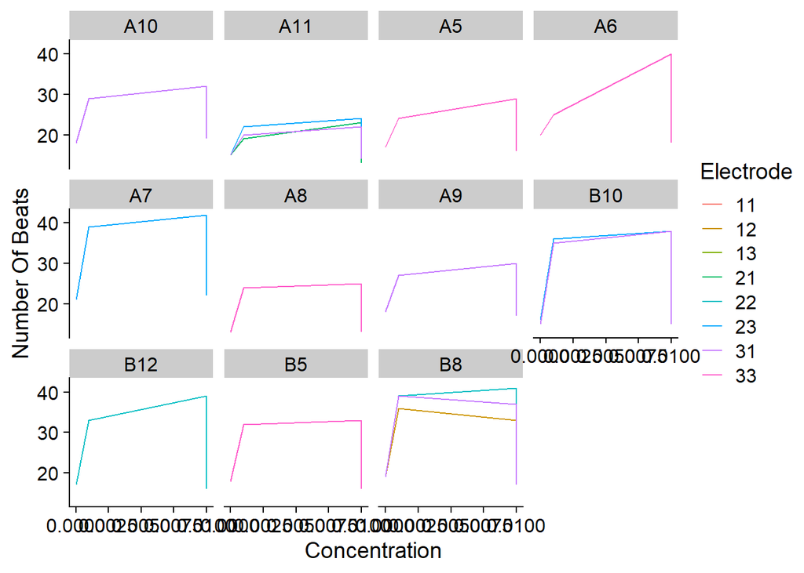

```r
ggplot(dat %>% filter(Drug == "DMSO"), aes(x = Concentration, y = `Number Of Beats`, colour = Electrode))+
  geom_line()+
  facet_wrap(~Well)
```

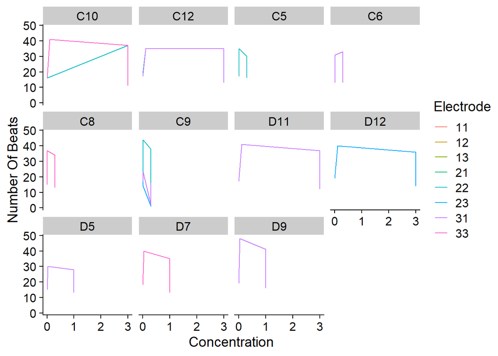

```r
ggplot(dat %>% filter(Drug == "Flec"), aes(x = Concentration, y = `Number Of Beats`, colour = Electrode))+
  geom_line()+
  facet_wrap(~Well)
```

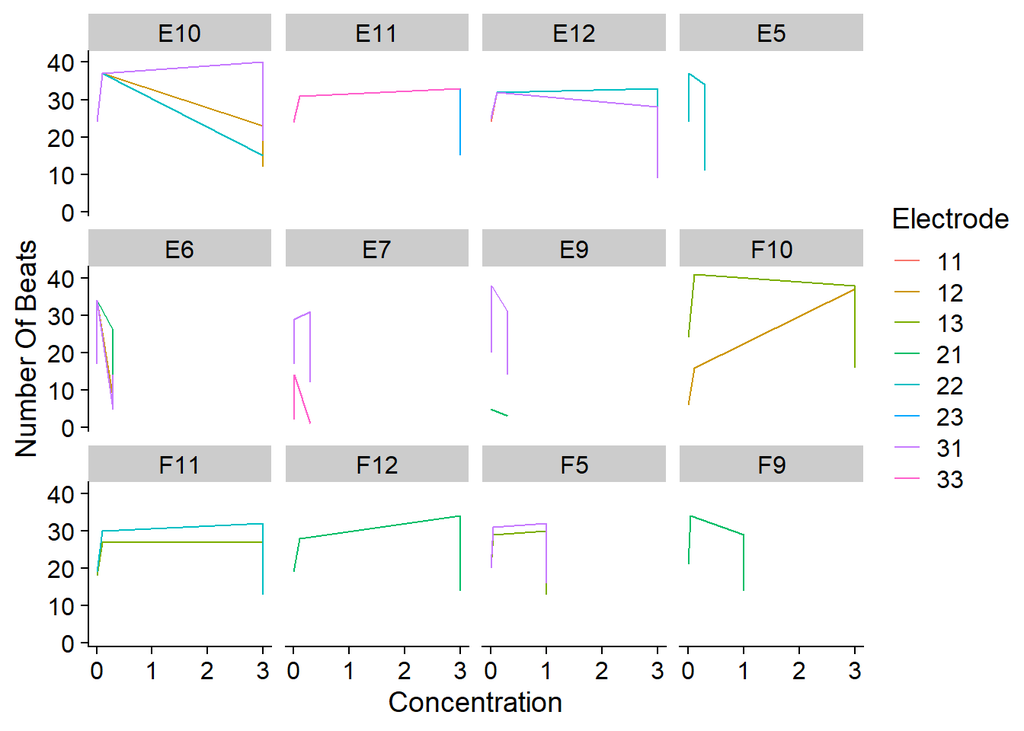

```r
#C10 misses electrode 22 at concentration 0.1 and electrode at concentration 23 long dose. Does not seem to give deviating data at other points, will be included.
#C9 Electrode 23 and 31 give deviating number of beats at dose 1 and 2. Will be excluded from those time points

ggplot(dat %>% filter(Drug == "E-4031"), aes(x = Concentration, y = `Number Of Beats`, colour = Electrode))+
  geom_line()+
  facet_wrap(~Well)
```

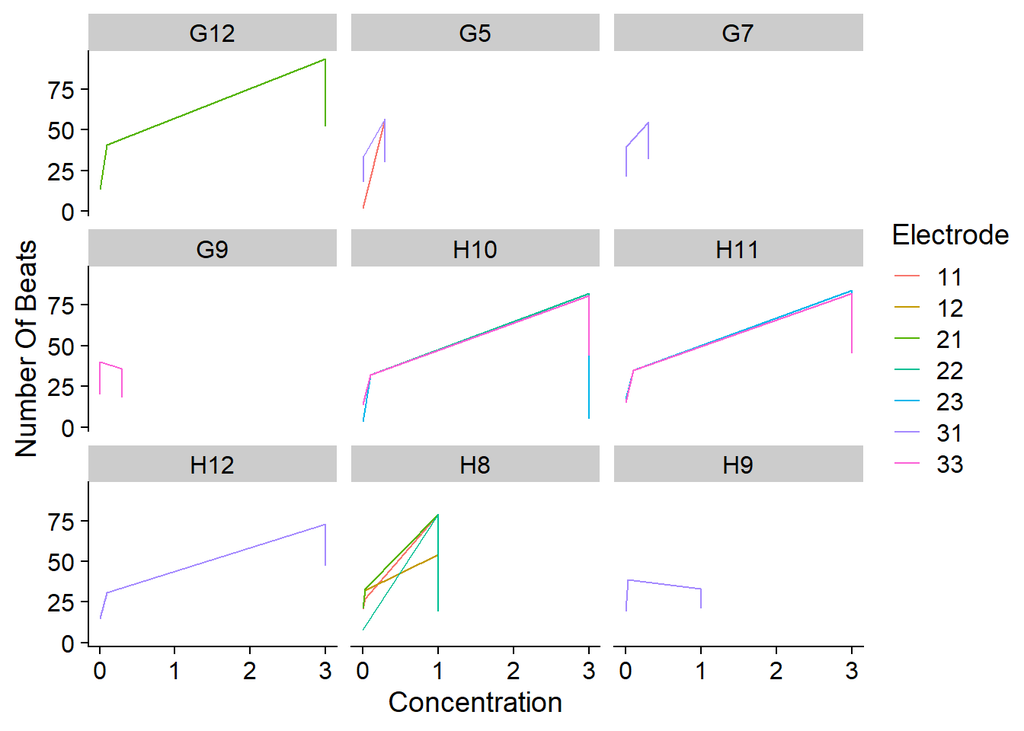

```r
#E10 has deviating data in electrode 12 and 22 at Dose 2 and dose 2 80 min, will be excluded from those time points
#F10 should reinspect the traces, only 2 electrodes give data which deviates from eachother. For now selecting electrode 13 which is closest to baseline mean of other wells.
#E7 electode 33 deviates from all other at all timepoints, should be removed.
#E6 electrode 12 and 31 deviate at dose 2 and dose 2 80 minutes, will be removed from these timepoints
#E9 electrode 21 has issues at baseline, remove from all timepoints
#E12 Electrode 31 deviates in Dose 2 and dose 2 80 minutes

ggplot(dat %>% filter(Drug == "BayK"), aes(x = Concentration, y = `Number Of Beats`, colour = Electrode))+
  geom_line()+
  facet_wrap(~Well)
```

```r
#G5 electrode 11 deviates at baseline, will be removed from all timepoints
#H8 multiple electrodes deviate at all time points, well will be completely removed.
#H10 electrode 23 deviates at baseline, remove completely

dat <- dat %>%
  filter(!(Well == "C9" & Electrode %in% c(23,31) & Settings %in% c("Dose 1", "Dose 2"))) %>%
  filter(!(Well == "E10" & Electrode %in% c(12, 22) & Settings %in% c("Dose 2", "Dose 2_80 min"))) %>%
  filter(!(Well == "F10" & Electrode %in% c(12))) %>%
  filter(!(Well == "E7" & Electrode %in% c(33))) %>%
  filter(!(Well == "E6" & Electrode %in% c(12,31) & Settings %in% c("Dose 2", "Dose 2_80 min"))) %>%
  filter(!(Well == "E9" & Electrode %in% c(21))) %>%
  filter(!(Well == "E12" & Electrode %in% c(31) & Settings %in% c("Dose 2", "Dose 2_80 min"))) %>%
  filter(!(Well == "G5" & Electrode %in% c(11))) %>%
  filter(!(Well == "H8")) %>%
    filter(!(Well == "H10" & Electrode %in% c(23))) #%>%

## all wells have SD below 5
dat %>% group_by(file, Drug, Concentration, Well) %>% ##Shows baseline electrodes  still with issues
  summarise(Beats = mean(`Number Of Beats`), Beats_median = median(`Number Of Beats`), Beats_sd = sd(`Number Of Beats`), m_Beats = getmode(`Number Of Beats`)) %>%
  arrange(desc(Beats_sd)) #%>% filter(file == "base")
```

```
## # A tibble: 168 × 8
## # Groups:   file, Drug, Concentration [34]
##    file            Drug  Concentration Well  Beats Beats_median Beats_sd m_Beats
##    <chr>           <chr>         <dbl> <chr> <dbl>        <dbl>    <dbl>   <dbl>
##  1 Batch_230818_R… DMSO          0.01  B8     38             39     3.83      41
##  2 Batch_230818_R… E-40…         0.3   E5     15.8           17     2.68      17
##  3 Batch_230818_R… E-40…         3     F11    31             32     2.24      32
##  4 Batch_230818_R… BayK          3     H10    43             44     2.24      44
##  5 Batch_230818_R… DMSO          0.001 B8     38.2           39     1.5       39
##  6 Batch_230818_R… DMSO          0.001 A11    21             22     1.41      22
##  7 Batch_230818_R… E-40…         0.1   F11    29.4           30     1.34      30
##  8 Batch_230818_R… E-40…         1     F5     15.5           16     1.22      16
##  9 Batch_230818_R… BayK          0     H11    15.5           15     1         15
## 10 Batch_230818_R… Flec          0     C12    18.5           19     1         19
## # ℹ 158 more rows
```

## Look at difference in dosing time interval (10 min vs 80 min) and DMSO effect

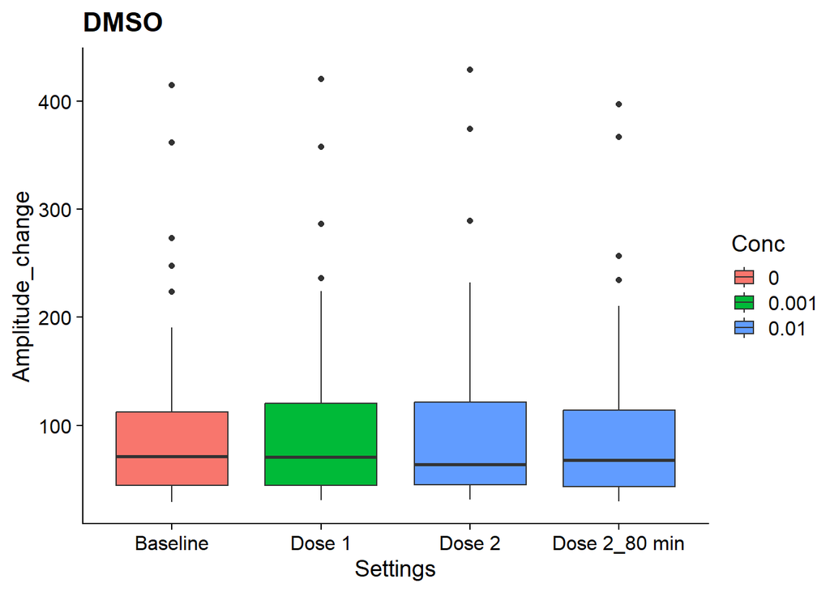

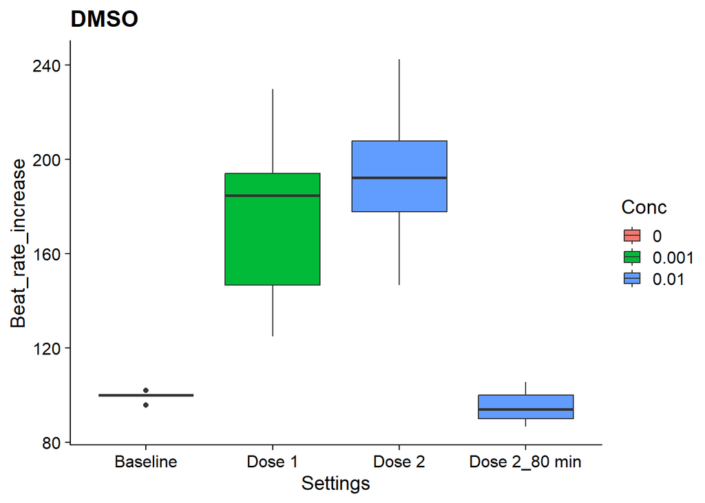

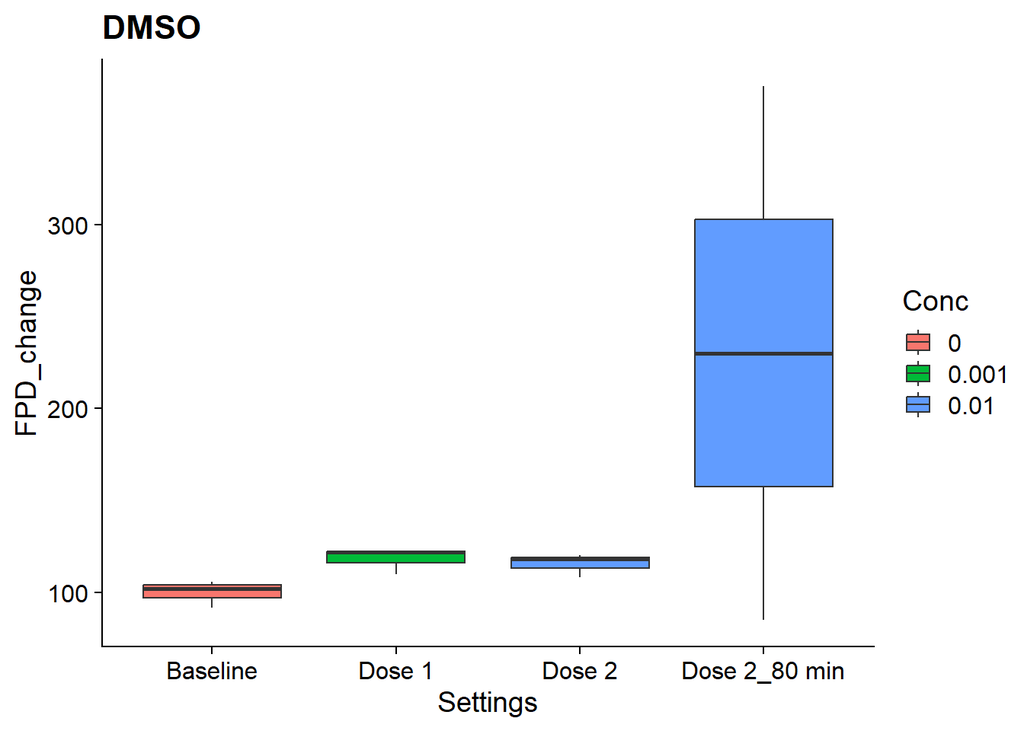

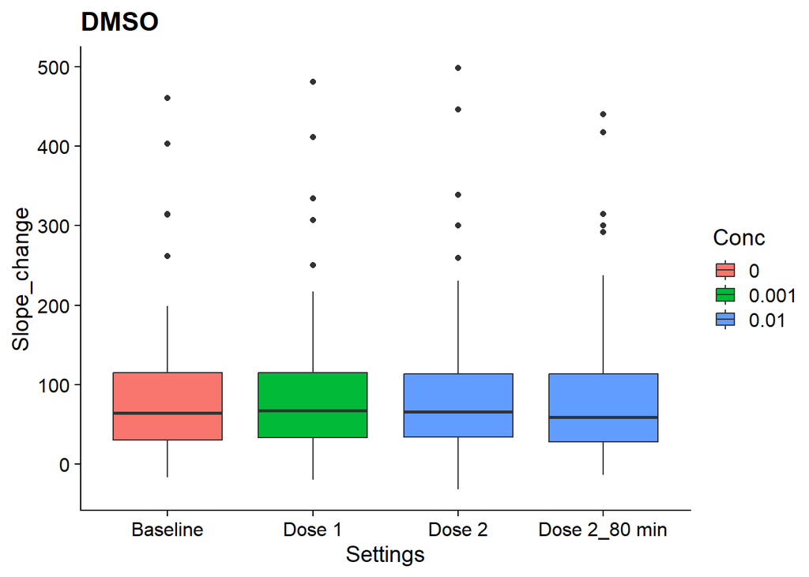

[output not shown]

```r
df <- dat
df$Conc <- factor(df$Concentration, levels = sort(unique(df$Concentration)))

bplot <- function(y, drg){
plot <- ggplot(df1 %>% filter(Drug == drg), aes(x = Settings, y = .data[[y]], fill = Conc))+
  geom_boxplot()+
  labs(title = drg)
plot(plot)
}

df1 <- df %>%
  group_by(Well, Drug) %>%
    mutate(baseline = `Spike Amplitude Mean (mV)`,
         Amplitude_change = `Spike Amplitude Mean (mV)`/mean(`Spike Amplitude Mean (mV)`[Concentration == 0]) * 100,
         Beat_rate_increase = `Number Of Beats`/mean(`Number Of Beats`[Concentration == 0])*100,
         FPD_change = `FPD Mean (ms)`/mean(`FPD Mean (ms)`[Concentration == 0])*100,
         Slope_change = `Spike Slope Mean (V / s)`/mean(`Spike Slope Mean (V / s)`[Concentration == 0])*100) %>%
  select(1:3, Amplitude_change, Beat_rate_increase, FPD_change, Slope_change, baseline, everything())


nams <- names(df1)[4:7]
sapply(nams, bplot, "DMSO")
```

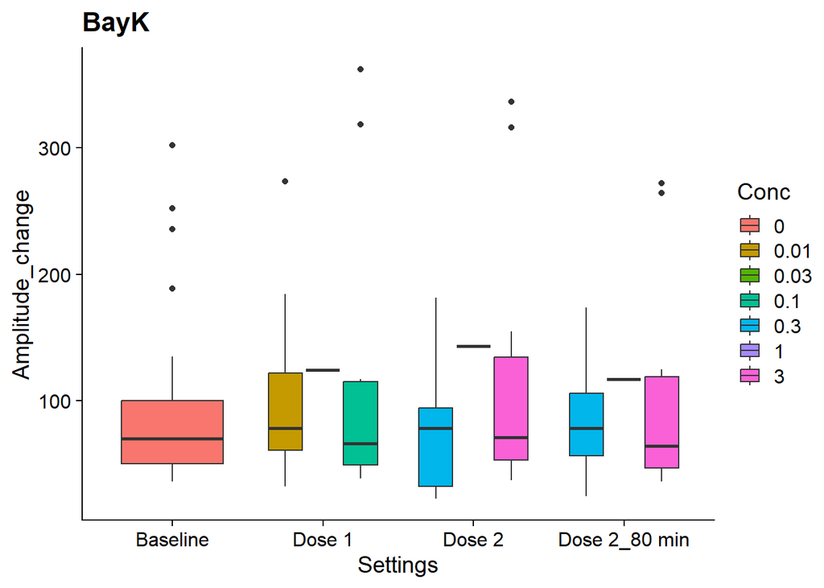

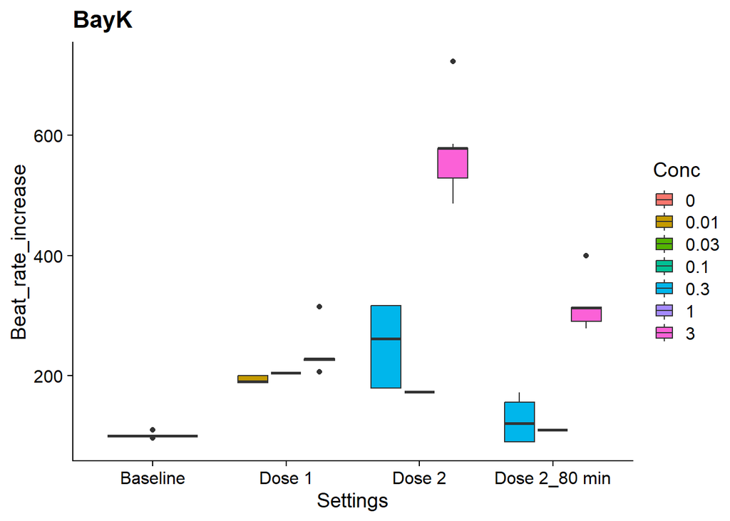

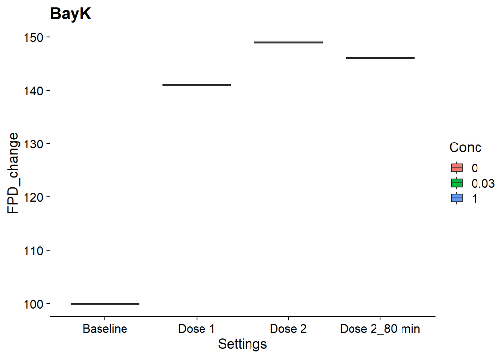

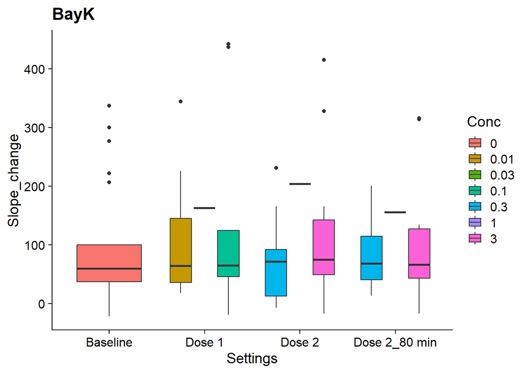

[output not shown]

```r
sapply(nams, bplot, "BayK")
```

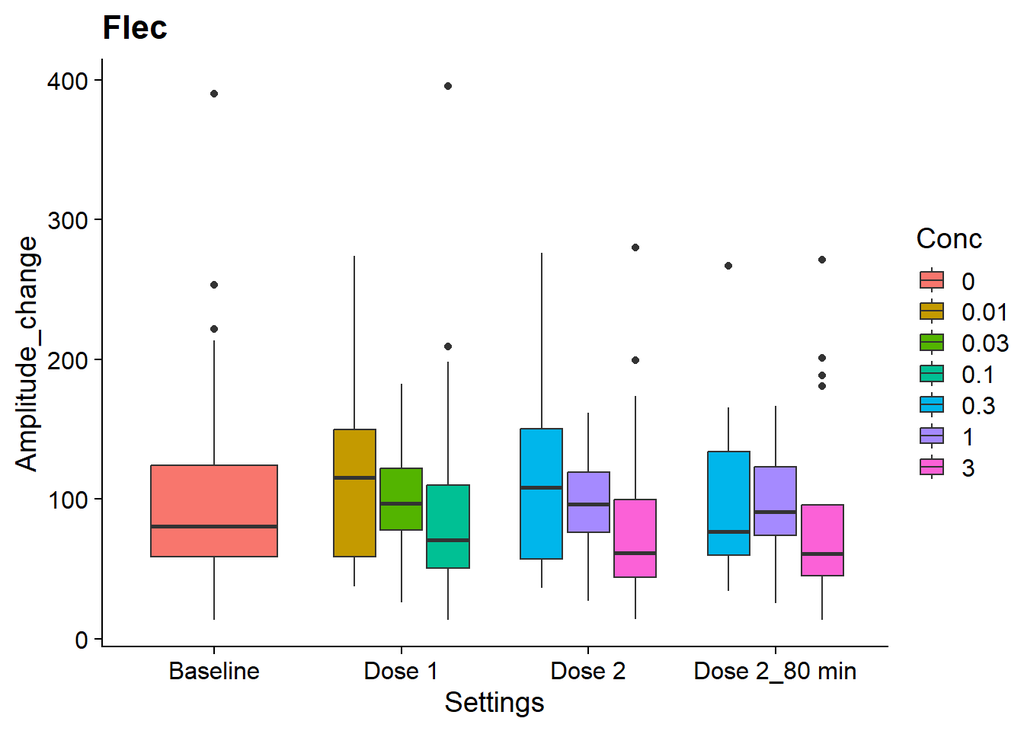

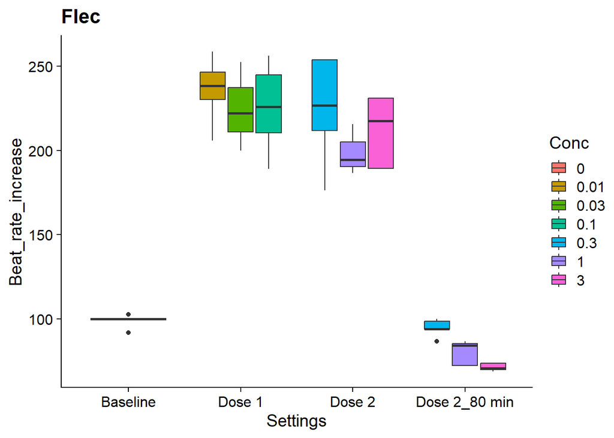

[figure not shown]

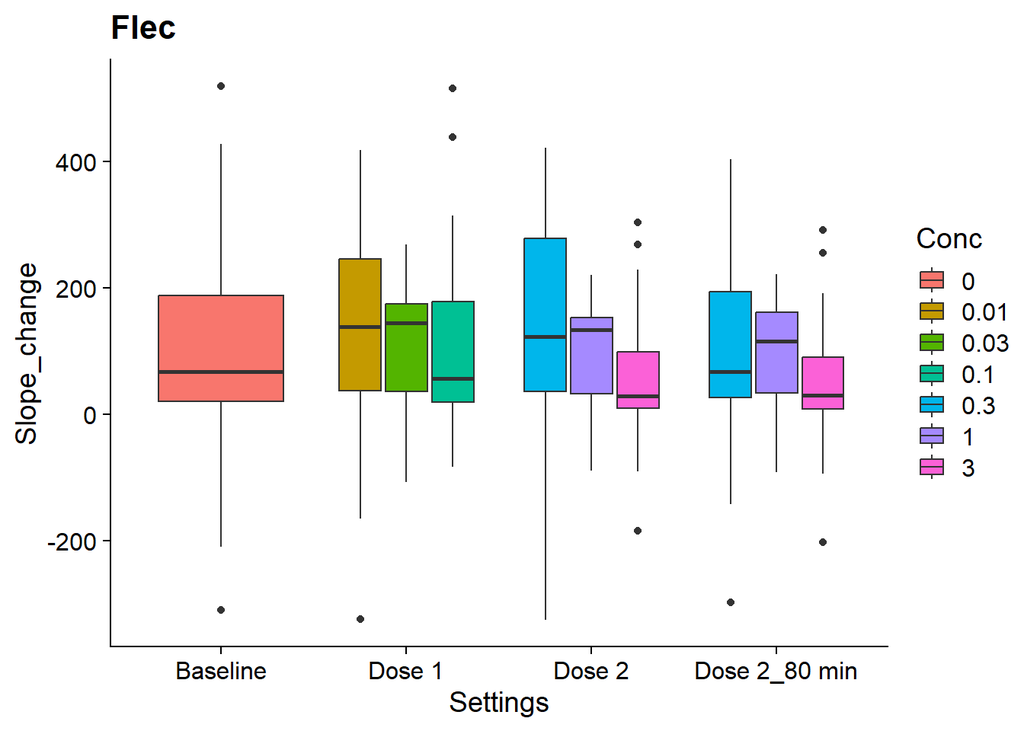

[output not shown]

```r
sapply(nams, bplot, "Flec")
```

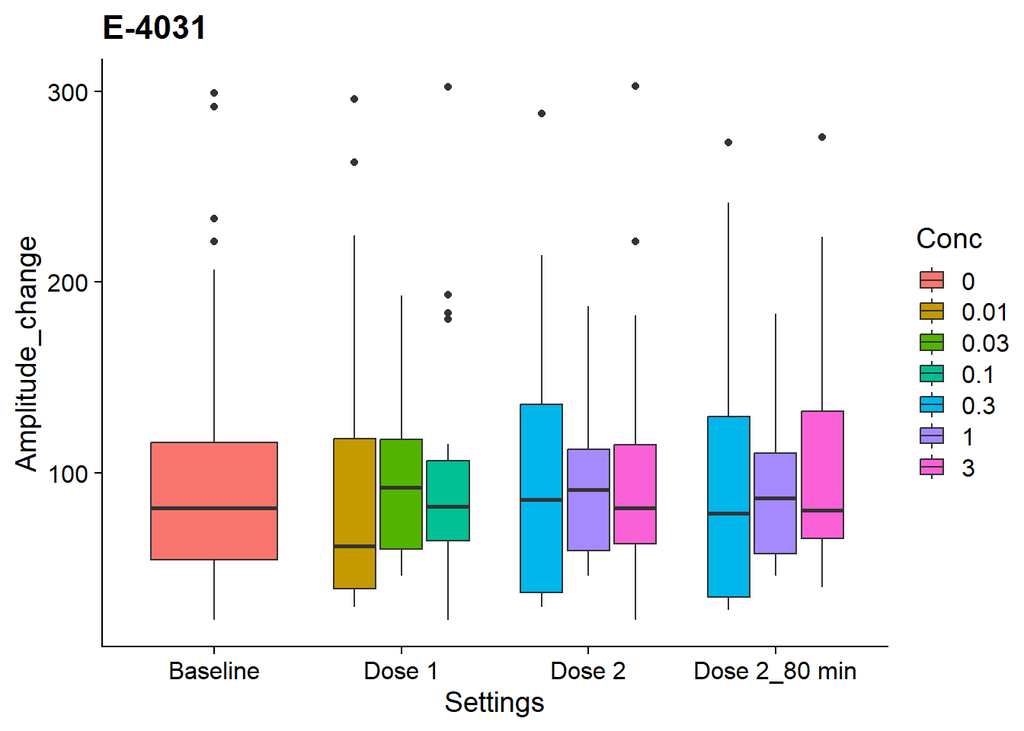

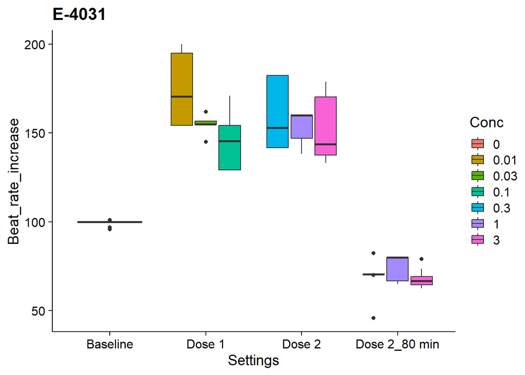

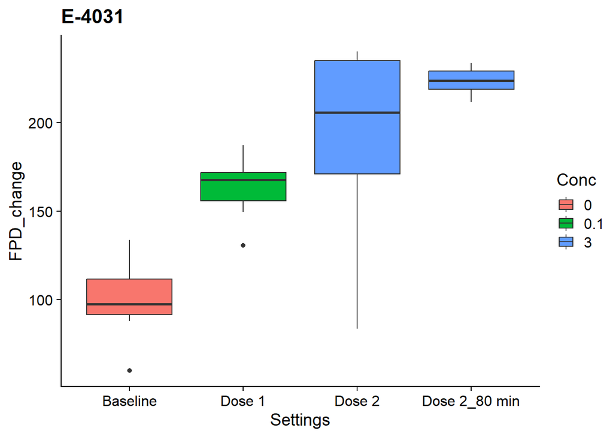

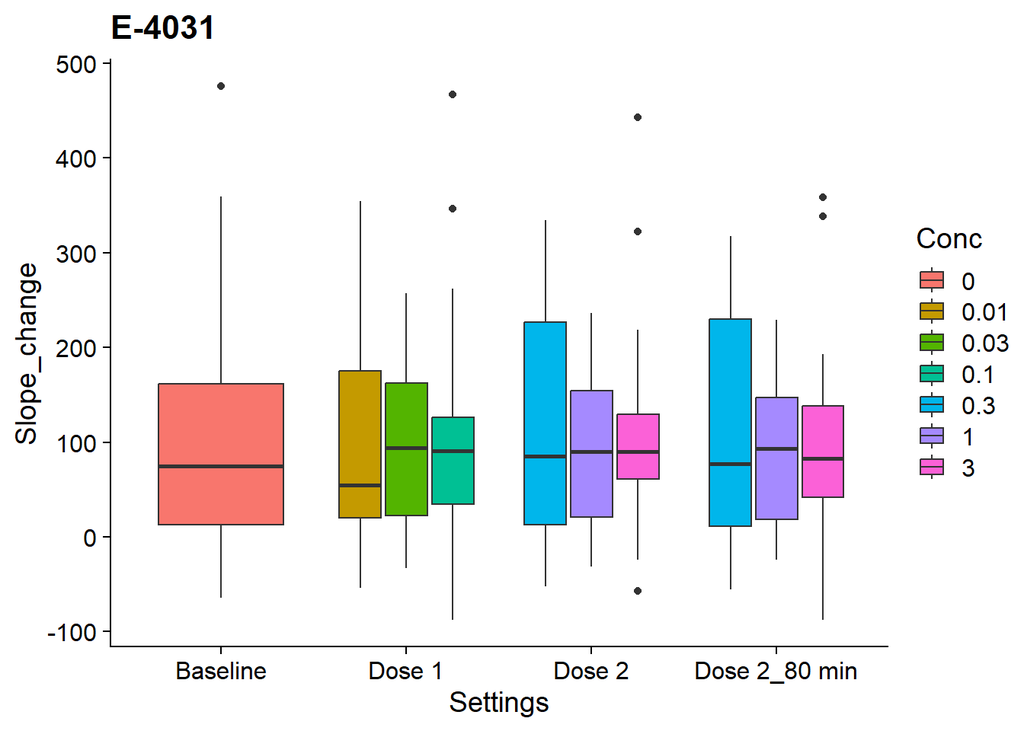

[output not shown]

```r
sapply(nams, bplot, "E-4031")
```

```r
pairwise.t.test(df1$Beat_rate_increase[df1$Drug == "DMSO"], df1$Concentration[df1$Drug == "DMSO"], p.adj = "none")
```

```
##
##  Pairwise comparisons using t tests with pooled SD
##
## data:  df1$Beat_rate_increase[df1$Drug == "DMSO"] and df1$Concentration[df1$Drug == "DMSO"]
##
##       0       0.001
## 0.001 9.5e-15 -
## 0.01  2.2e-08 0.00012
##
## P value adjustment method: none
```

```r
pairwise.t.test(df1$Beat_rate_increase[df1$Drug == "Flec"], df1$Concentration[df1$Drug == "Flec"], p.adj = "none")
```

```
##
##  Pairwise comparisons using t tests with pooled SD
##
## data:  df1$Beat_rate_increase[df1$Drug == "Flec"] and df1$Concentration[df1$Drug == "Flec"]
##
##      0       0.01    0.03    0.1     0.3     1
## 0.01 < 2e-16 -       -       -       -       -
## 0.03 4.9e-09 0.60701 -       -       -       -
## 0.1  < 2e-16 0.51731 0.97118 -       -       -
## 0.3  3.1e-06 1.9e-07 0.00084 1.0e-06 -       -
## 1    0.01103 3.0e-07 0.00028 1.6e-06 0.33608 -
## 3    0.00016 9.8e-10 6.5e-05 4.1e-09 0.25829 0.88906
##
## P value adjustment method: none
```

## Calculate mean statistics, uncorrected for DMSO

```r
dat_mean <- dat %>% group_by(file, Well, Drug, Settings) %>% summarise(across(where(is.double), ~mean(.x, na.rm=TRUE))) %>%
  ungroup() %>% group_by(Well, Drug) %>%
  mutate(baseline = `Spike Amplitude Mean (mV)`,
         Amplitude_change = `Spike Amplitude Mean (mV)`/`Spike Amplitude Mean (mV)`[Concentration == 0] * 100,
         Beat_rate_increase = `Number Of Beats`/`Number Of Beats`[Concentration == 0]*100,
         FPD_change = `FPD Mean (ms)`/`FPD Mean (ms)`[Concentration == 0]*100,
         Slope_change = `Spike Slope Mean (V / s)`/`Spike Slope Mean (V / s)`[Concentration == 0]*100) %>%
  select(1:3, Amplitude_change, Beat_rate_increase, FPD_change, Slope_change, baseline, everything())
dat_mean
```

```
## # A tibble: 168 × 32
## # Groups:   Well, Drug [42]
##    file  Well  Drug  Amplitude_change Beat_rate_increase FPD_change Slope_change
##    <chr> <chr> <chr>            <dbl>              <dbl>      <dbl>        <dbl>
##  1 Batc… A10   DMSO               100                100        100          100
##  2 Batc… A11   DMSO               100                100        NaN          100
##  3 Batc… A5    DMSO               100                100        NaN          100
##  4 Batc… A6    DMSO               100                100        100          100
##  5 Batc… A7    DMSO               100                100        NaN          100
##  6 Batc… A8    DMSO               100                100        100          100
##  7 Batc… A9    DMSO               100                100        NaN          100
##  8 Batc… B10   DMSO               100                100        NaN          100
##  9 Batc… B12   DMSO               100                100        NaN          100
## 10 Batc… B5    DMSO               100                100        NaN          100
## # ℹ 158 more rows
## # ℹ 25 more variables: baseline <dbl>, Settings <chr>, Concentration <dbl>,
## #   `Number Of Beats` <dbl>, `Number Of FPD Beats` <dbl>,
## #   `Beat Period Mean (s)` <dbl>, `Beat Period StdDev (s)` <dbl>,
## #   `Beat Period Median (s)` <dbl>, `Beat Period MAD (s)` <dbl>,
## #   `Beat Period Irregularity (%)` <dbl>, `Spike Slope Mean (V / s)` <dbl>,
## #   `Spike Slope StdDev (V / s)` <dbl>, `Spike Slope Median (V / s)` <dbl>, …
```

```r
glimpse(dat_mean)
```

```
## Rows: 168
## Columns: 32
## Groups: Well, Drug [42]
## $ file                           <chr> "Batch_230818_RvH23D002_MEA_drug_test_D…
## $ Well                           <chr> "A10", "A11", "A5", "A6", "A7", "A8", "…
## $ Drug                           <chr> "DMSO", "DMSO", "DMSO", "DMSO", "DMSO",…
## $ Amplitude_change               <dbl> 100, 100, 100, 100, 100, 100, 100, 100,…
## $ Beat_rate_increase             <dbl> 100, 100, 100, 100, 100, 100, 100, 100,…
## $ FPD_change                     <dbl> 100, NaN, NaN, 100, NaN, 100, NaN, NaN,…
## $ Slope_change                   <dbl> 100, 100, 100, 100, 100, 100, 100, 100,…
## $ baseline                       <dbl> 0.8370000, 0.4668000, 0.3520000, 0.4595…
## $ Settings                       <chr> "Baseline", "Baseline", "Baseline", "Ba…
## $ Concentration                  <dbl> 0, 0, 0, 0, 0, 0, 0, 0, 0, 0, 0, 0, 0, …
## $ `Number Of Beats`              <dbl> 18.00000, 15.00000, 17.00000, 20.00000,…
## $ `Number Of FPD Beats`          <dbl> 2.666667, 0.000000, 0.000000, 0.250000,…
```

[output cut: 20 more lines]

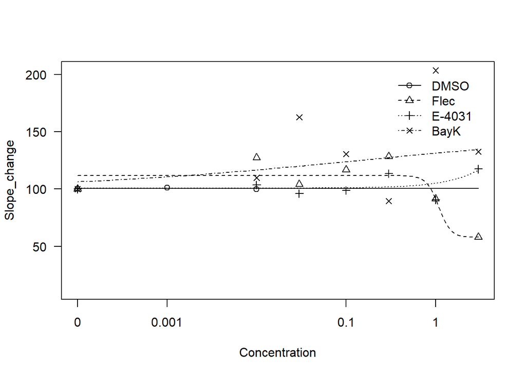

```r
Slope <- dat_mean %>% filter(! Settings == "Dose 2_80 min") %>%
  drc::drm(data=., Slope_change ~ Concentration, fct = drc::LL.4(names = c("Slope", "Lower", "Upper", "ED50")), curveid = Drug)
Amplitude <- dat_mean%>% filter(! Settings == "Dose 2_80 min",! Drug %in% c("DMSO", "E-4031")) %>%
  drc::drm(data=., Amplitude_change ~ Concentration, fct = drc::LL.4(names = c("Slope", "Lower", "Upper", "ED50")), curveid = Drug)
BR <- dat_mean %>% filter(! Settings == "Dose 2_80 min",! Drug == "DMSO") %>%
  drc::drm(data=., Beat_rate_increase ~ Concentration, fct = drc::LL.4(names = c("Slope", "Lower", "Upper", "ED50")), curveid = Drug)
FPD <- dat_mean%>% filter(! Settings == "Dose 2_80 min",! Drug == "DMSO") %>%
  drc::drm(data=., FPD_change ~ Concentration, fct = drc::LL.4(names = c("Slope", "Lower", "Upper", "ED50")), curveid = Drug)

plot(Slope)
```

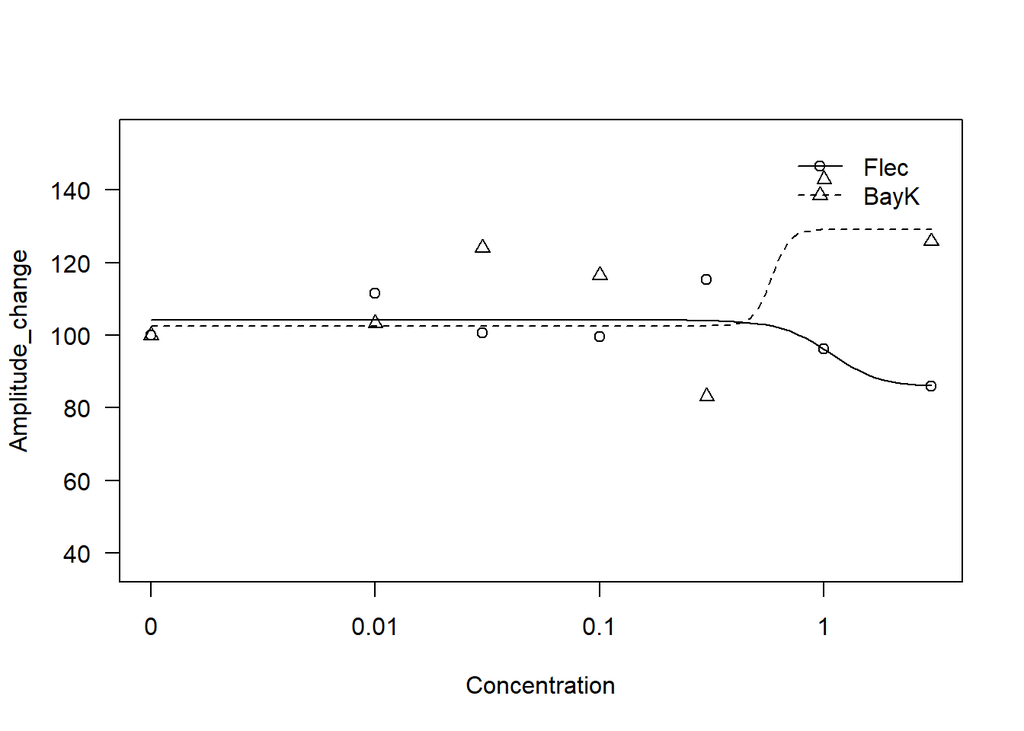

```r
plot(Amplitude)
```

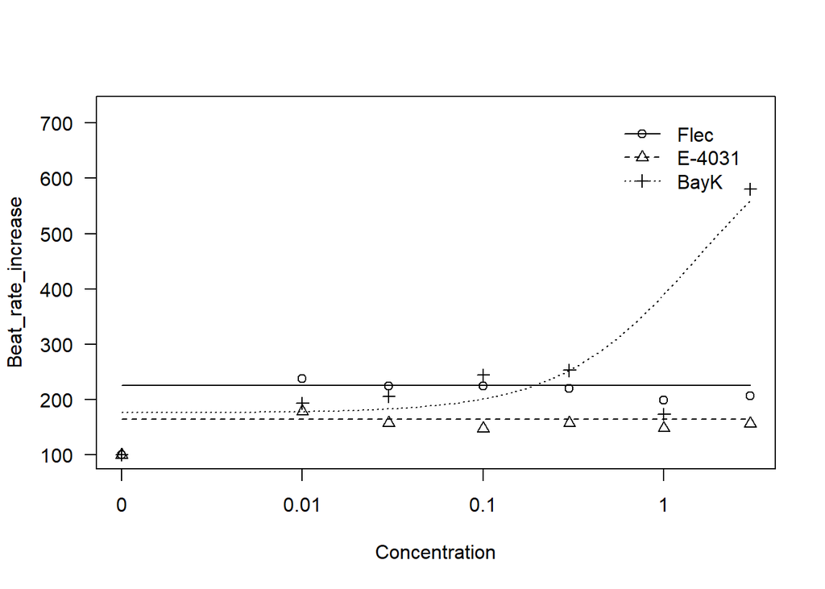

```r
plot(BR)
```

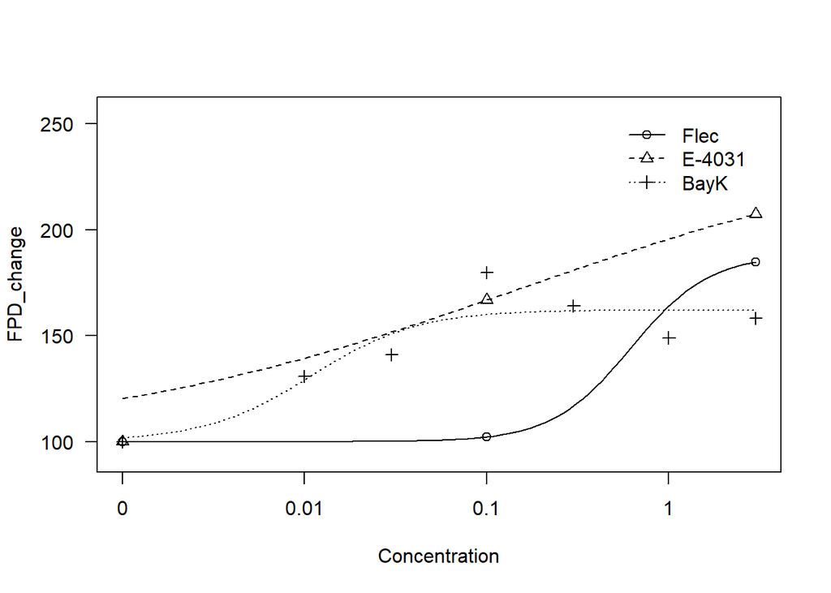

```r
plot(FPD)
```

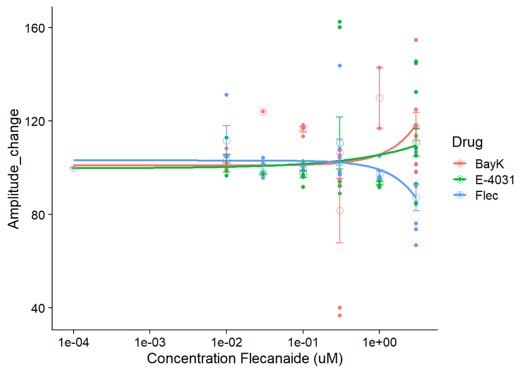

```r
dat_mean <- dat_mean %>% mutate(Conc = ifelse(Concentration == 0, 0.0001, Concentration))
dat <- dat_mean

splot <- function(dat, drg, y){
plot <- ggplot(dat %>% filter(Drug %in% drg), aes(x = Conc, y = .data[[y]], colour = Drug))+
  stat_summary(fun = mean, geom = "point", shape = 1, size = 3)+
  geom_point()+
  geom_smooth(method = drm, method.args = list(fct= L.4()), se = FALSE)+
  stat_summary(fun.data = mean_se, geom = "errorbar", width = 0.1, size = 0.5)+
  scale_x_log10()+
#plot
#  geom_vline(data = vert, aes(xintercept = EC50, colour = Line), linetype = "dashed")+
#    scale_colour_npg()+
  labs(#y = "Amplitude decrease (%) ",
       x = "Concentration Flecanaide (uM)")
plot(plot)
}

splot(dat_mean, c("E-4031", "BayK", "Flec"), "Amplitude_change")
```

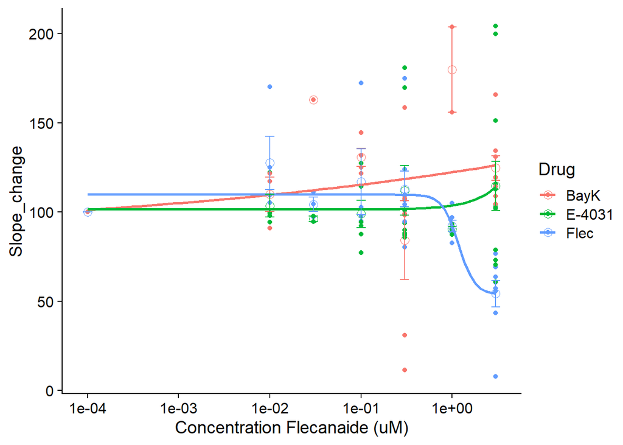

```r
splot(dat_mean, c("E-4031", "BayK", "Flec"), "Slope_change")
```

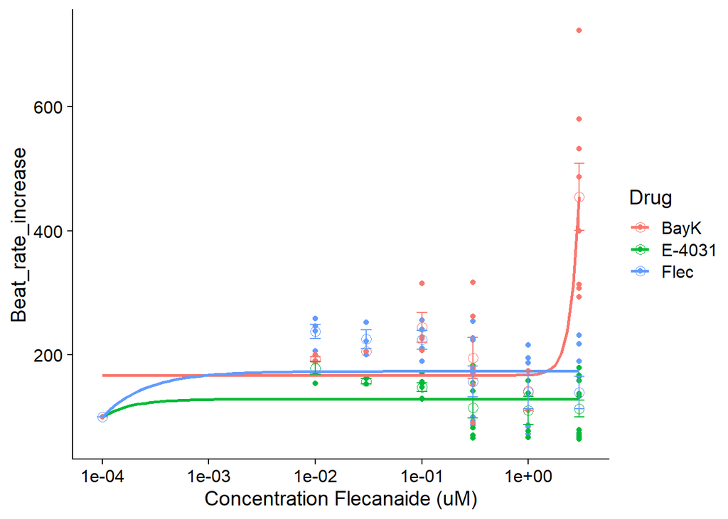

```r
splot(dat_mean, c("E-4031", "BayK", "Flec"), "Beat_rate_increase")
```

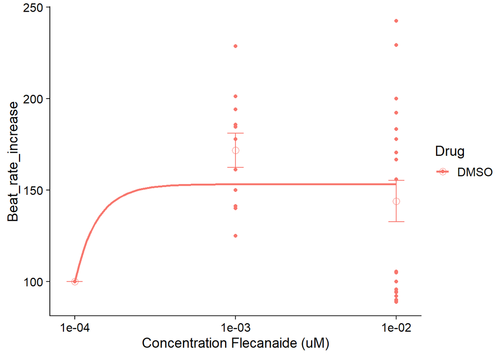

```r
splot(dat_mean, c("DMSO"), "Beat_rate_increase")
```

dat_mean <- dat %>% group_by(Line, Well, Treatment, Electrode) %>% mutate(baseline = `Spike Amplitude Mean (mV)`, Amplitude_change = `Spike Amplitude Mean (mV)`/`Spike Amplitude Mean (mV)`[file == “Baseline”] * 100,) %>% select(1:3, Amplitude_change, baseline, everything()) %>% group_by(file, Line, Well, Treatment) %>% summarise(across(where(is.double), ~mean(.x, na.rm=TRUE))) %>% ungroup()

flec <- dat_mean %>% filter(Treatment == “Flec”) %>% ungroup() %>% arrange(Line, file) %>% mutate(Concentration = c(rep(c(0,0.1,0.3,1,3,10,30), each = 3, times = 2), rep(c(0,0.1,0.3,1,3,10,30), each = 2))) %>% select(1:3, Concentration, everything()) flec

model2 <- drm(Amplitude_change ~ Concentration, fct = LL.4(names = c(“Slope”, “Lower”, “Upper”, “ED50”)), data = flec %>% filter(Line == “Iso 1”))  
summary(model2) plot(model2)

model3 <- drm(Amplitude_change ~ Concentration, fct = LL.4(names = c(“Slope”, “Lower”, “Upper”, “ED50”)), data = flec %>% filter(Line == “Ctrl”))  
summary(model3) plot(model3)

DMSO <- dat_mean %>% filter(Treatment == “DMSO”) %>% ungroup() %>% arrange(Line, file) %>% mutate(Concentration = c(rep(c(0,0.0002,0.000667,0.002,0.00667,0.02,0.0667), each = 2), rep(c(0,0.0002,0.000667,0.002,0.00667,0.02,0.0667), each = 2, times = 2))) %>% select(1:3, Concentration, everything()) DMSO

model <- drm(Amplitude_change ~ Concentration, fct = LL.4(names = c(“Slope”, “Lower”, “Upper”, “ED50”)), data = DMSO %>% filter(Line == “Pt 1”))  
summary(model) plot(model)

model <- drm(Amplitude_change ~ Concentration, fct = LL.4(names = c(“Slope”, “Lower”, “Upper”, “ED50”)), data = DMSO %>% filter(Line == “Iso 1”))  
summary(model) plot(model)

model <- drm(Amplitude_change ~ Concentration, fct = LL.4(names = c(“Slope”, “Lower”, “Upper”, “ED50”)), data = DMSO %>% filter(Line == “Ctrl”))  
summary(model) plot(model)

vert <- data.frame(Line = c(“Pt 1”, “Iso 1”, “Ctrl”), EC50 = c(model1$fit$par[4], model2$fit$par[4], model3$fit$par[4]))

ggplot(flec, aes(x = Concentration, y = Amplitude_change, colour = Line))+ stat_summary(fun = mean, geom = “point”, shape = 1, size = 3)+ geom_smooth(method = drm, method.args = list(fct= L.4()), se = FALSE)+ scale_x_log10()+ geom_vline(data = vert, aes(xintercept = EC50, colour = Line))

ggplot(dat_mean %>% filter(file == “Baseline”), aes(x = Line, y = `Beat Period Mean (s)`, fill = Line))+ stat_summary(fun = mean, geom = “bar”)+ stat_summary(fun.data = mean_sdl, geom = “errorbar”, size = 0.5, width = 0.1)+ scale_y_continuous(expand = c(0,0))

seq_plot <- function(y) { plot <- ggplot(dat_mean, aes_string(x = “Line”, y = paste0(“`",y, "`”), fill = “Line”))+ stat_summary(fun = mean, geom= “bar”)+ geom_point()+ stat_summary(fun.data = mean_se, geom = “errorbar”)  
plot(plot) }

plot_vars <- names(dat_mean)[!str_detect(names(dat_mean), “sd”)]

sapply(plot_vars, seq_plot)